# DATA SCIENCE LATAM

UN ESPACIO PARA NUNCA PARAR DE APRENDER!!

Francisco Zambrano Cruz. Mayo 2020.

[figure not shown]

# Histogramas con GGPLOT2

Es relativamente sencillo construir un histograma con `ggplot2` gracias a la función `geom_histogram()`.

Solo se necesita una variable numérica en la entrada.

Tenga en cuenta que se activa un mensaje de advertencia: debemos ocuparnos del ancho del intervalo.

## Histograma básico con `geom_histogram`

```
Warning message:
"package 'tidyverse' was built under R version 3.6.2"-- Attaching packages --------------------------------------- tidyverse 1.3.0 --
`stat_bin()` using `bins = 30`. Pick better value with `binwidth`.
```

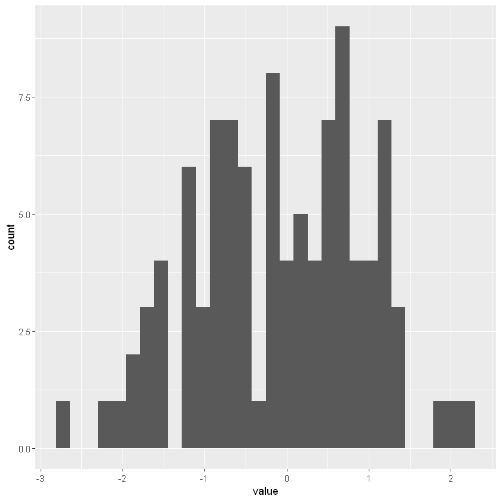

```r
# library
library(tidyverse)
library(ggplot2)

# dataset:
data=data.frame(value=rnorm(100))

# basic histogram
p <- ggplot(data, aes(x=value)) +
  geom_histogram()

p
```

## Combiando el tamaño del intervalo con `binwidth`

```r
# Libraries
#library(tidyverse)
library(hrbrthemes)

# Load dataset from github
data1 <- read.table("https://raw.githubusercontent.com/holtzy/data_to_viz/master/Example_dataset/1_OneNum.csv", header=TRUE)
```

```r
head(data1)
```

| price |
| --- |
| 75 |
| 104 |
| 369 |
| 300 |
| 92 |
| 64 |

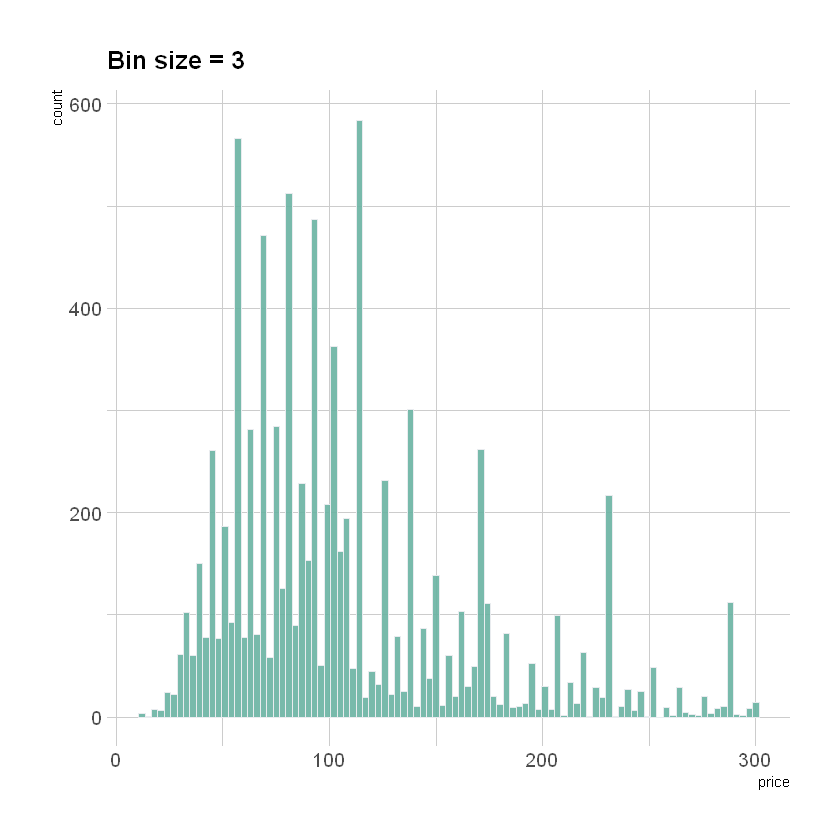

```r
options(warn=-1)
p1 <- data1 %>%
  filter( price<300 ) %>%
  ggplot( aes(x=price)) +
    geom_histogram( binwidth=3, fill="#69b3a2", color="#e9ecef", alpha=0.9) +
    ggtitle("Bin size = 3") +
    theme_ipsum() +
    theme(
      plot.title = element_text(size=15)
    )
p1
```

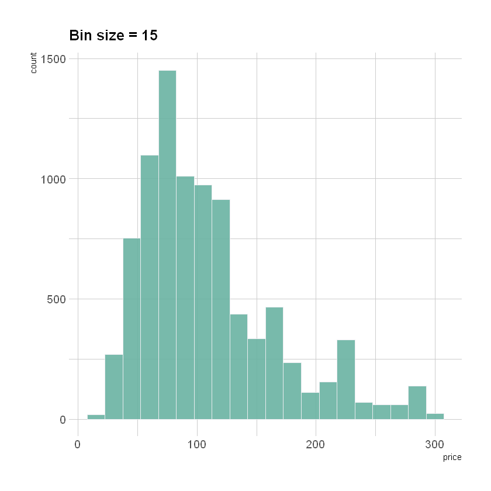

```r
p2 <- data1 %>%
  filter( price<300 ) %>%
  ggplot( aes(x=price)) +
    geom_histogram( binwidth=15, fill="#69b3a2", color="#e9ecef", alpha=0.9) +
    ggtitle("Bin size = 15") +
    theme_ipsum() +
    theme(
      plot.title = element_text(size=15)
    )
p2
```

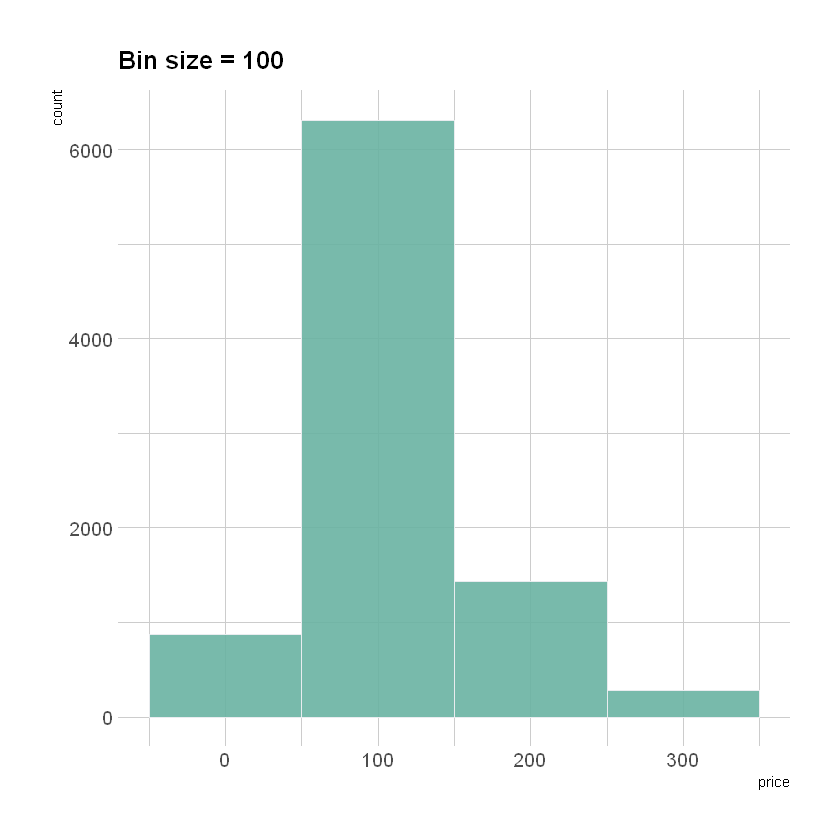

```r
p3 <- data1 %>%
  filter( price<300 ) %>%
  ggplot( aes(x=price)) +
    geom_histogram( binwidth=100, fill="#69b3a2", color="#e9ecef", alpha=0.9) +
    ggtitle("Bin size = 100") +
    theme_ipsum() +
    theme(
      plot.title = element_text(size=15)
    )
p3
```

## Histograma espejo con 2 grupos

```r
# Dummy data
data2 <- data.frame(
  var1 = rnorm(1000),
  var2 = rnorm(1000, mean=2)
)

head(data2)
```

| var1 | var2 |
| --- | --- |
| 0.9326705 | 1.8648509 |
| 1.3217445 | 0.9235628 |
| -0.3581750 | 0.8483185 |
| 2.2364754 | 1.3918619 |
| -0.7821574 | 3.3218094 |
| -0.4936999 | 0.7307503 |

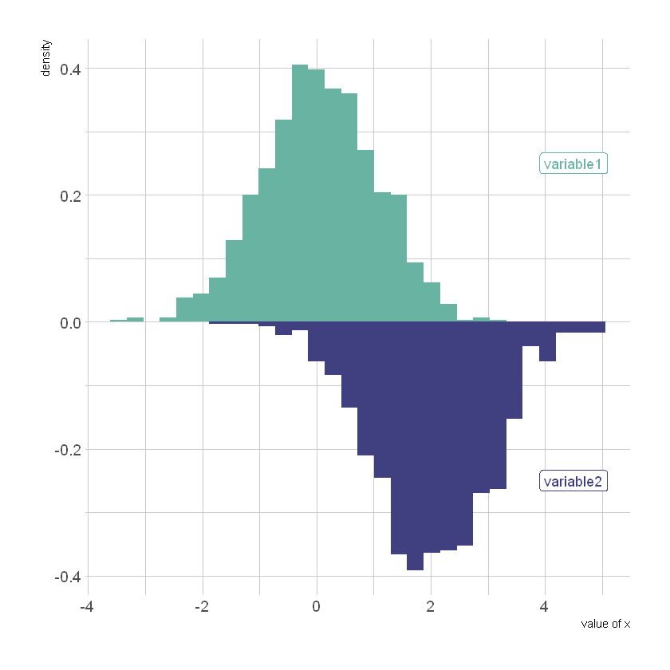

```r
p4 <- ggplot(data2, aes(x=x) ) +
  # histograma de arriba
  geom_histogram( aes(x = var1, y = ..density..), fill="#69b3a2" ) +
  geom_label( aes(x=4.5, y=0.25, label="variable1"), color="#69b3a2") +
  # histograma de abajo
  geom_histogram( aes(x = var2, y = -..density..), fill= "#404080") +
  geom_label( aes(x=4.5, y=-0.25, label="variable2"), color="#404080") +
  theme_ipsum() +
  xlab("value of x")

p4
```

## Histograma de 2 grupos en el mismo eje

Si el número de grupo o variable que tiene es relativamente bajo, puede mostrarlos todos en el mismo eje, utilizando un poco de transparencia para asegurarse de no ocultar ningún dato.

```r
# library
library(ggplot2)
library(dplyr)
library(hrbrthemes)
```

```r
# contruimos un data set con diferentes distribuciones

data3 <- data.frame(
  type = c( rep("variable 1", 1000), rep("variable 2", 1000) ),
  value = c( rnorm(1000), rnorm(1000, mean=4) )
)

head(data3)
tail(data3)
```

| type | value |
| --- | --- |
| variable 1 | -0.03369892 |
| variable 1 | -1.76692647 |
| variable 1 | -1.36049457 |
| variable 1 | 1.84121747 |
| variable 1 | -0.72188553 |
| variable 1 | 0.00481516 |

|  | type | value |
| --- | --- | --- |
| 1995 | variable 2 | 4.435086 |
| 1996 | variable 2 | 4.912115 |
| 1997 | variable 2 | 4.590103 |
| 1998 | variable 2 | 4.312076 |
| 1999 | variable 2 | 3.946728 |
| 2000 | variable 2 | 4.619705 |

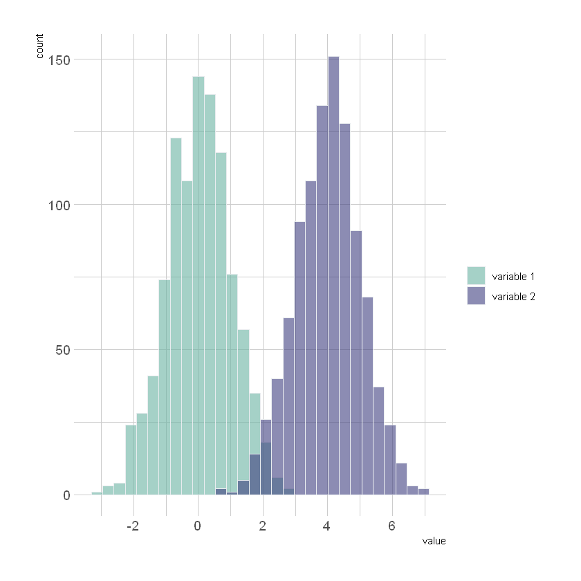

```r
p5 <- data3 %>%
  ggplot( aes(x=value, fill=type)) +
    geom_histogram( color="#e9ecef", alpha=0.6, position = 'identity') +
    scale_fill_manual(values=c("#69b3a2", "#404080")) +
    theme_ipsum() +
    labs(fill="")

p5
```

## Histograma de varios grupos con `facet_wrap()`

Si el número de grupo que necesita representar es alto, dibujarlos en el mismo eje a menudo resulta en una figura desordenada e ilegible.

Una buena solución es usar un múltiplo pequeño donde cada grupo se represente en una fracción de la ventana, lo que hace que la figura sea fácil de leer. Esto es bastante fácil de construir gracias a la función `facet_wrap()` de ggplot2.

```r
options(warn=-1)

#install.packages("viridis")
library(tidyverse)
library(hrbrthemes)
library(viridis)
library(forcats)

# creamos y limpiamos un data set
data4 <- read.table("https://raw.githubusercontent.com/zonination/perceptions/master/probly.csv", header=TRUE, sep=",")
data4 <- data4 %>%
  gather(key="text", value="value") %>%
  mutate(text = gsub("\\.", " ",text)) %>%
  mutate(value = round(as.numeric(value),0))

head(data4)
```

| text | value |
| --- | --- |
| Almost Certainly | 95 |
| Almost Certainly | 95 |
| Almost Certainly | 95 |
| Almost Certainly | 95 |
| Almost Certainly | 98 |
| Almost Certainly | 95 |

```r
tail(data4)
```

|  | text | value |
| --- | --- | --- |
| 777 | Chances Are Slight | 15 |
| 778 | Chances Are Slight | 20 |
| 779 | Chances Are Slight | 10 |
| 780 | Chances Are Slight | 5 |
| 781 | Chances Are Slight | 10 |
| 782 | Chances Are Slight | 15 |

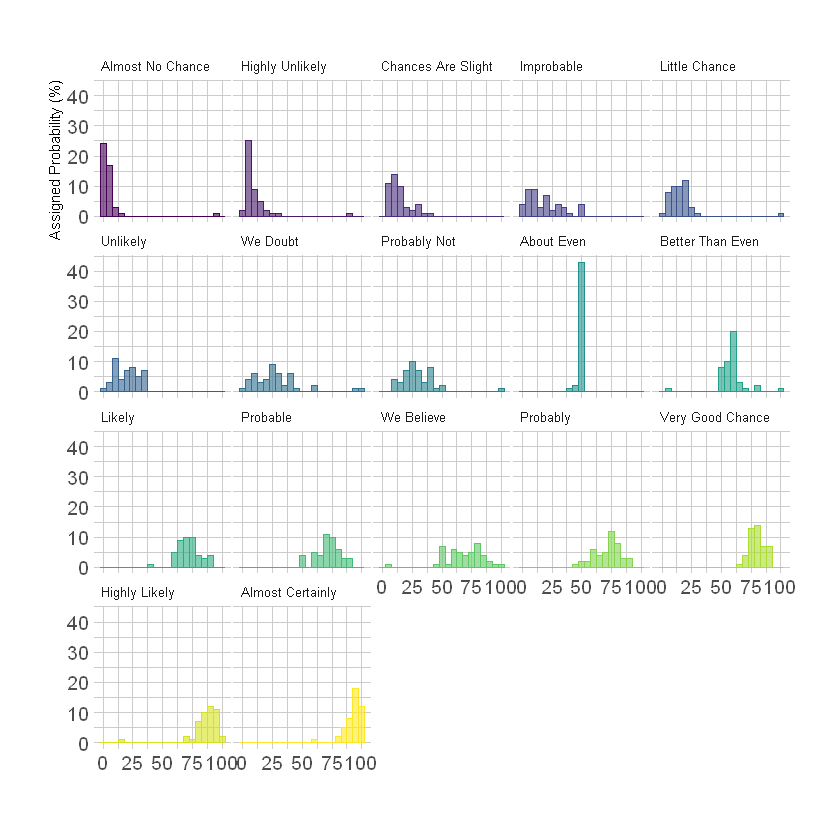

```r
p6 <- data4 %>%
  mutate(text = fct_reorder(text, value)) %>%
  ggplot( aes(x=value, color=text, fill=text)) +
    geom_histogram(alpha=0.6, binwidth = 5) +
    scale_fill_viridis(discrete=TRUE) +
    scale_color_viridis(discrete=TRUE) +
    theme_ipsum() +
    theme(
      legend.position="none",
      panel.spacing = unit(0.1, "lines"),
      strip.text.x = element_text(size = 8)
    ) +
    xlab("") +
    ylab("Assigned Probability (%)") +
    facet_wrap(~text)

p6
```

## Grafica de histogramas marginales con funcion `ggMarginal()`

|  | mpg | cyl | disp | hp | drat | wt | qsec | vs | am | gear | carb |
| --- | --- | --- | --- | --- | --- | --- | --- | --- | --- | --- | --- |
| Mazda RX4 | 21.0 | 6 | 160 | 110 | 3.90 | 2.620 | 16.46 | 0 | 1 | 4 | 4 |
| Mazda RX4 Wag | 21.0 | 6 | 160 | 110 | 3.90 | 2.875 | 17.02 | 0 | 1 | 4 | 4 |
| Datsun 710 | 22.8 | 4 | 108 | 93 | 3.85 | 2.320 | 18.61 | 1 | 1 | 4 | 1 |
| Hornet 4 Drive | 21.4 | 6 | 258 | 110 | 3.08 | 3.215 | 19.44 | 1 | 0 | 3 | 1 |
| Hornet Sportabout | 18.7 | 8 | 360 | 175 | 3.15 | 3.440 | 17.02 | 0 | 0 | 3 | 2 |
| Valiant | 18.1 | 6 | 225 | 105 | 2.76 | 3.460 | 20.22 | 1 | 0 | 3 | 1 |

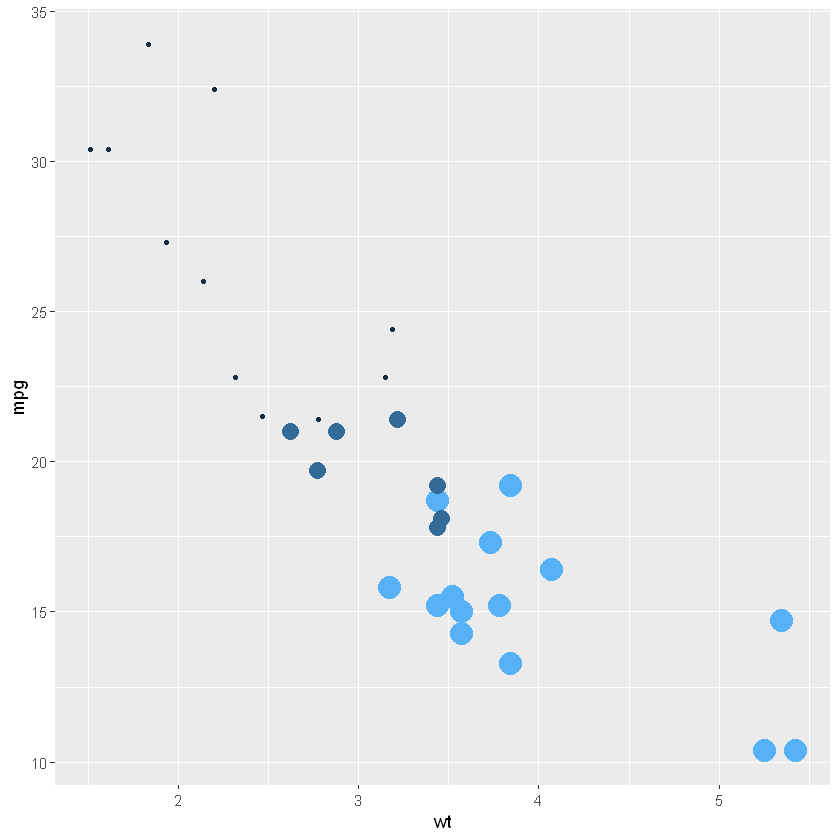

```r
# library
library(ggplot2)
library(ggExtra)

# The mtcars dataset is proposed in R
head(mtcars)

# classic plot :
p7 <- ggplot(mtcars, aes(x=wt, y=mpg, color=cyl, size=cyl)) +
      geom_point() +
      theme(legend.position="none")
p7
```

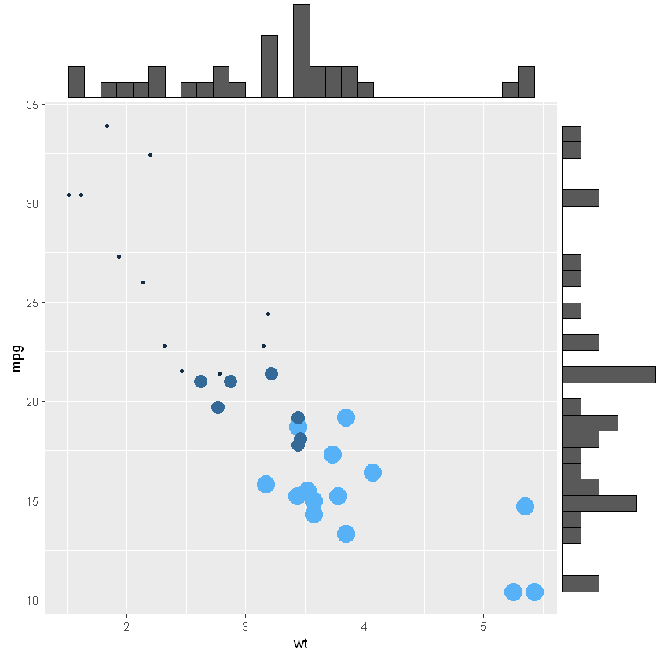

```r
# Grafica del histograma marginal
p8 <- ggMarginal(p7, type="histogram")
p8
```

Tres ejemplos adicionales para mostrar una posible personalización:

- Cambiar el tamaño del histograma marginal de la grafica con size
- Apariencia de grafica marginal personalizada con todos los parámetros habituales
- Mostrar solo una grafica marginal con margins = 'x' o margins = 'y'

|  | mpg | cyl | disp | hp | drat | wt | qsec | vs | am | gear | carb |
| --- | --- | --- | --- | --- | --- | --- | --- | --- | --- | --- | --- |
| Mazda RX4 | 21.0 | 6 | 160 | 110 | 3.90 | 2.620 | 16.46 | 0 | 1 | 4 | 4 |
| Mazda RX4 Wag | 21.0 | 6 | 160 | 110 | 3.90 | 2.875 | 17.02 | 0 | 1 | 4 | 4 |
| Datsun 710 | 22.8 | 4 | 108 | 93 | 3.85 | 2.320 | 18.61 | 1 | 1 | 4 | 1 |
| Hornet 4 Drive | 21.4 | 6 | 258 | 110 | 3.08 | 3.215 | 19.44 | 1 | 0 | 3 | 1 |
| Hornet Sportabout | 18.7 | 8 | 360 | 175 | 3.15 | 3.440 | 17.02 | 0 | 0 | 3 | 2 |
| Valiant | 18.1 | 6 | 225 | 105 | 2.76 | 3.460 | 20.22 | 1 | 0 | 3 | 1 |

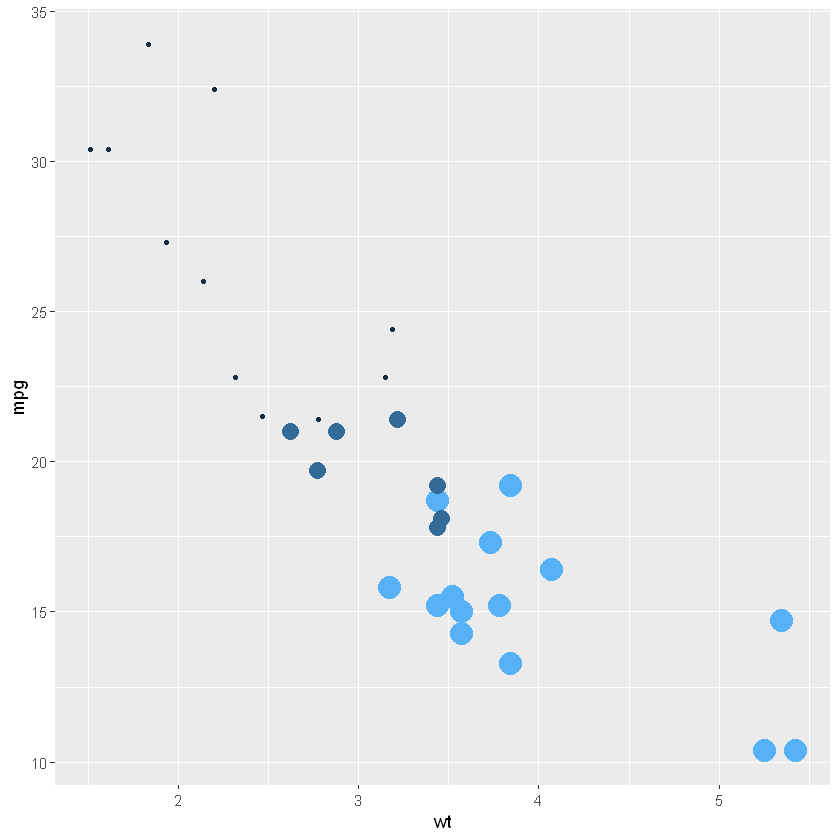

```r
# library
library(ggplot2)
library(ggExtra)

head(mtcars)

# classic plot :
p9 <- ggplot(mtcars, aes(x=wt, y=mpg, color=cyl, size=cyl)) +
      geom_point() +
      theme(legend.position="none")
p9
```

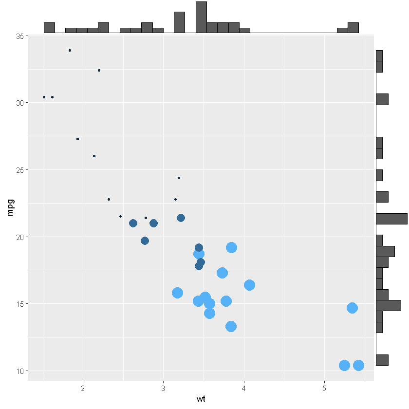

```r
p10 <- ggMarginal(p9, type="histogram", size=10)
p10
```

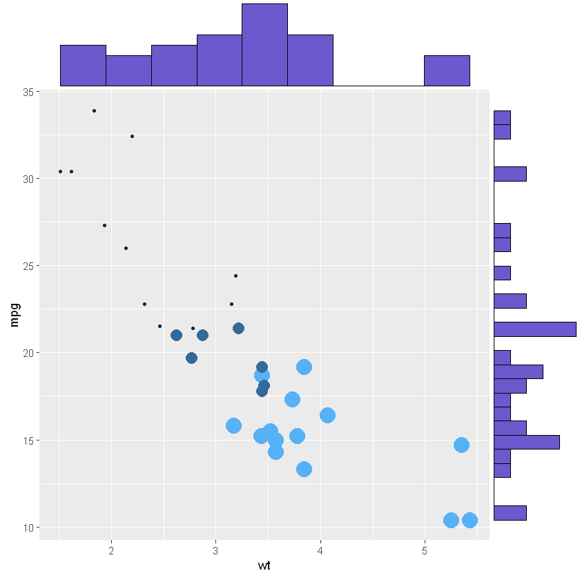

```r
p12 <- ggMarginal(p9, type="histogram", fill = "slateblue", xparams = list(  bins=10))
p12
```

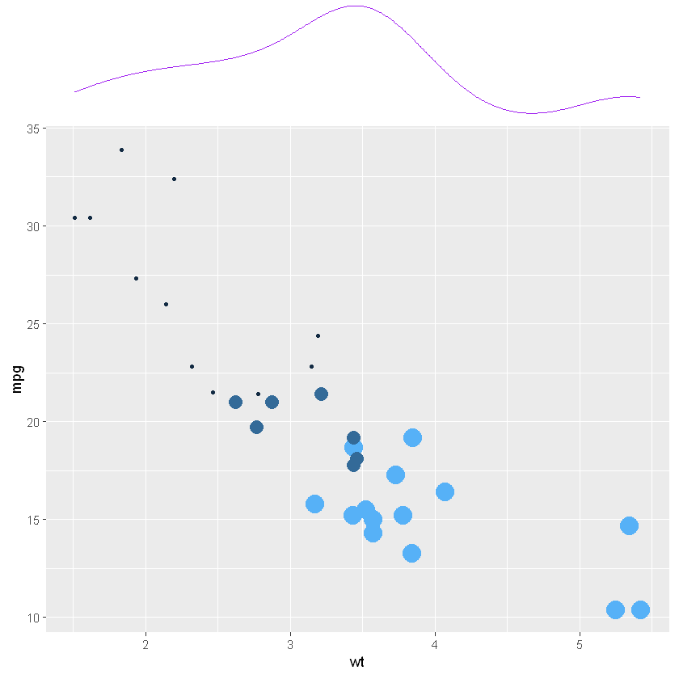

```r
p13 <- ggMarginal(p9, margins = 'x', color="purple", size=4)
p13
```